# ExampleThinkShrink.R

VNOB-0735

2023-01-17

# Think before you shrink, Example script

Script: Mark van de Wiel, mark.vdwiel@amsterdamumc.nl; Package ‘shrinkage’, version 1.2, written by Gwenaël Leday, g.g.r.leday@wur.nl

This script illustrates usage of R-packages ‘mgcv’, ‘rstan’ and ‘shrinkage’ for the purpose of regression-based prediction of continuous and binary response. We focus on the assets of these methods as compared to default alternatives like simple, one-penalty ridge regression. In particular:

1. Covariate-group specific shrinkage
2. Confidence intervals that propagate uncertainty of the penalty parameter(s)
3. Local shrinkage using a hierarchial prior (Bayesian setting: rstan, shrinkage)

The manuscript “Think before you shrink: Alternatives to default shrinkage methods can improve prediction accuracy, calibration and coverage” illustrates the potential benefits of 1), 2) and 3) for improving prediction accuracy, coverage and calibration, respectively.

Note that scripts for reproducing the results presented in the manuscript are available from the same repository. These contain more extensive coding, also for other (more default) shrinkage methods, such as ridge and Firth, as discussed in the manuscript.

## Preliminaries

loading libraries; using suppressWarnings() to avoid clutter

```r
library(mgcv) #available from CRAN
```

To install ‘shrinkage’ package from github run: library(devtools); install_github(“gleday/shrinkage”). If you haven’t installed devtools yet, first run: install.packages(“devtools”). Alternatively (without devtools), download the entire folder of source material from GitHub repo gleday/shrinkage and install from source using install.packages(“[path]/shrinkage-master/”, repos=NULL, type=“source”)

```r
library(shrinkage)
```

## Linear regression

Load example training and test data sets (train and test objects). These are subsets of the large synthetic Helius data set, also available on the repository. ADJUST PATH, OR USE setwd()!

```r
load("dsynth_example.Rdata")

dim(train)
```

```
## [1] 50 18
```

```r
head(train)
```

```
##              sbp        age gender etnicityGhanese etnicityMaroccan
## 7612  -0.9006274 -0.4781296      1              -1               -1
## 13904 -0.9856249 -1.7668695      1              -1               -1
## 11172  1.7059645  1.2654597     -1              -1               -1
## 14995 -0.3056445  1.3412680     -1              -1               -1
## 17448  1.9042921  0.4315692     -1              -1               -1
## 20958  0.1193434 -1.0845954      1              -1               -1
##       etnicitySurinam etnicityTurkish smoking  packyears coffee        bmi
## 7612                1              -1      -1  0.6188318     -1 -1.0180141
## 13904              -1              -1      -1  2.9513372      1 -0.5553630
## 11172               1              -1      -1  1.3076420     -1  1.8650480
## 14995               1              -1      -1  2.1257596     -1 -0.6216956
## 17448               1              -1       1 -0.6568348     -1  1.5318030
## 20958              -1               1       1 -0.6568348     -1 -0.3236844
##        lab_gluc   lab_chol     Noise 1    Noise 2     Noise 3     Noise 4
## 7612  -1.721232  0.5134407 -0.83679613  1.7043904 -1.45518278 -0.16943624
## 13904 -0.489739 -1.0614321 -1.33944375 -1.7760694  0.10389708 -2.70700329
## 11172  3.004979  1.5698772 -0.02707338  0.1518353 -0.04800441  1.60053209
## 14995  1.937454  1.5307499 -0.18851301  0.0723719  0.20428558 -0.01030845
## 17448  0.822193  0.4938771  1.73577653 -0.7343097 -0.38195930 -0.39939224
## 20958 -1.308126  0.2884589  1.07243139 -1.9563406  0.52211267  0.20449668
##           Noise 5
## 7612  -0.02317117
## 13904  2.21979597
## 11172 -0.24716021
## 14995 -0.13452074
## 17448  0.15025386
## 20958 -1.66033191
```

```r
colnames(train)
```

```
##  [1] "sbp"              "age"              "gender"           "etnicityGhanese"
##  [5] "etnicityMaroccan" "etnicitySurinam"  "etnicityTurkish"  "smoking"
##  [9] "packyears"        "coffee"           "bmi"              "lab_gluc"
## [13] "lab_chol"         "Noise 1"          "Noise 2"          "Noise 3"
## [17] "Noise 4"          "Noise 5"
```

Retrieve response (sbp) and covariates

```r
Y <- train[,1]
X <- train[,-1]

dim(test)
```

```
## [1] 100  18
```

```r
head(test)
```

```
##               sbp        age gender etnicityGhanese etnicityMaroccan
## 2344   0.17600839 -0.1748967      1              -1               -1
## 236   -0.95729242 -0.4781296     -1              -1                1
## 1841  -0.39064201  0.8864186      1              -1               -1
## 5527   0.06267831  0.5073774      1               1               -1
## 17703 -0.73063226 -0.9329790     -1              -1               -1
## 3354  -0.44730705  0.6589939     -1              -1                1
##       etnicitySurinam etnicityTurkish smoking  packyears coffee        bmi
## 2344               -1              -1      -1  2.0934328     -1 -0.5841546
## 236                -1              -1      -1 -0.5399608     -1 -0.2404012
## 1841               -1              -1       1  1.6184770     -1 -1.0317018
## 5527               -1              -1       1 -0.6568348     -1  1.0250869
## 17703               1              -1       1 -0.6568348      1 -1.0150558
## 3354               -1              -1      -1 -0.1992857     -1 -0.7491923
##         lab_gluc   lab_chol    Noise 1    Noise 2     Noise 3    Noise 4
## 2344   0.1363214  0.5427862  1.0717496 -1.0000737 -0.76808939  0.7370036
## 236   -0.2215272  0.9829680  0.1732106 -0.7981477 -0.08052276  0.8763141
## 1841  -0.4897390 -1.2375048 -0.8083533  0.7184486 -0.11857756  1.8228867
## 5527   0.9072758 -0.4745230 -0.1689894  0.7171298  0.10520037 -0.2078629
## 17703 -0.9502778 -0.8168866 -0.2229705  0.3234789 -1.05862322 -1.9299992
## 3354  -0.2215272 -0.3082320  0.8550646 -1.3698289 -1.64847166 -0.2614601
##          Noise 5
## 2344   1.1731407
## 236    1.7843259
## 1841   1.2173745
## 5527   0.7735248
## 17703  0.4456210
## 3354  -1.3446968
```

```r
Yte <- test[,1]
Xte <- test[,-1]
```

## Fit models

### mgcv

nr of covariates

```r
ncov <- ncol(X)
ncov
```

```
## [1] 17
```

names of covariates

```r
colnames(X)
```

```
##  [1] "age"              "gender"           "etnicityGhanese"  "etnicityMaroccan"
##  [5] "etnicitySurinam"  "etnicityTurkish"  "smoking"          "packyears"
##  [9] "coffee"           "bmi"              "lab_gluc"         "lab_chol"
## [13] "Noise 1"          "Noise 2"          "Noise 3"          "Noise 4"
## [17] "Noise 5"
```

Covariate group 1: age (1), gender (2), bmi (10). Covariate group 2: all others.

```r
whknown <- c(1,2,10)
```

Create two vectors with 1’s at position of the covariates that are in the group and 0’s elsewhere

```r
diag1 <- rep(0,ncov);diag1[whknown] <- 1;diag2 <- rep(0,ncov);diag2[-whknown] <- 1;
diag1
```

```
##  [1] 1 1 0 0 0 0 0 0 0 1 0 0 0 0 0 0 0
```

```r
diag2
```

```
##  [1] 0 0 1 1 1 1 1 1 1 0 1 1 1 1 1 1 1
```

Specification of penalty matrix for gam. Argument ‘sp=-1’ indicates that penalties need to be estimated.

```r
PP2 <- list(X=list(diag(diag1),diag(diag2)),sp=-1)
```

Fit ridge regression model and estimate multiple penalties using maximum (marginal) likelihood. Argument ‘scale=-1’ indicates that error variance should be estimated as well

```r
pred2 <- gam(Y ~ 1+X,family="gaussian",paraPen=PP2,method="ML",scale=-1)
```

Coefficients and their uncertainties

```r
summary(pred2)
```

```
##
## Family: gaussian
## Link function: identity
##
## Formula:
## Y ~ 1 + X
##
## Parametric coefficients:
##                    Estimate Std. Error t value Pr(>|t|)
## (Intercept)        0.038382   0.178280   0.215  0.83060
## Xage               0.140622   0.126291   1.113  0.27194
## Xgender           -0.249618   0.114886  -2.173  0.03559 *
## XetnicityGhanese  -0.019640   0.092619  -0.212  0.83311
## XetnicityMaroccan -0.067632   0.084188  -0.803  0.42637
## XetnicitySurinam   0.058592   0.080874   0.724  0.47285
## XetnicityTurkish  -0.022278   0.089370  -0.249  0.80438
## Xsmoking           0.091197   0.081191   1.123  0.26782
## Xpackyears        -0.130172   0.072203  -1.803  0.07871 .
## Xcoffee            0.042161   0.085262   0.494  0.62358
## Xbmi               0.374250   0.127530   2.935  0.00543 **
## Xlab_gluc          0.072028   0.082111   0.877  0.38545
## Xlab_chol          0.065740   0.082986   0.792  0.43278
## XNoise 1          -0.004608   0.080960  -0.057  0.95488
## XNoise 2          -0.066593   0.072629  -0.917  0.36452
## XNoise 3          -0.035734   0.074823  -0.478  0.63546
## XNoise 4           0.077532   0.073662   1.053  0.29867
## XNoise 5           0.029030   0.070546   0.412  0.68283
## ---
## Signif. codes:  0 '***' 0.001 '**' 0.01 '*' 0.05 '.' 0.1 ' ' 1
##
##
## R-sq.(adj) =  0.437   Deviance explained = 52.6%
## -ML =  65.47  Scale est. = 0.61413   n = 50
```

Retrieve estimated penalties for both groups

```r
pred2$sp
```

```
##        X1        X2
##  6.819633 59.566013
```

```r
pred2test <- predict.gam(pred2,list(X=Xte),se.fit=T,unconditional=T)
pred2test$fit[1:10]
```

```
##           1           2           3           4           5           6
## -0.58355097  0.20705366 -0.56322443  0.37972380 -0.07761498 -0.04077983
##           7           8           9          10
## -0.03730118  0.42468484 -0.12721835 -0.65911634
```

```r
pred2test$se.fit[1:10]
```

```
##         1         2         3         4         5         6         7         8
## 0.3643030 0.3621086 0.3966181 0.3070744 0.3373756 0.3947352 0.3531766 0.2729506
##         9        10
## 0.4200854 0.5016019
```

Confidence intervals of predictions

```r
cis <- rbind(pred2test$fit - 1.96*pred2test$se.fit, pred2test$fit + 1.96*pred2test$se.fit)
cis[,1:10]
```

```
##               1          2         3          4          5          6
## [1,] -1.2975849 -0.5026792 -1.340596 -0.2221421 -0.7388712 -0.8144608
## [2,]  0.1304829  0.9167866  0.214147  0.9815897  0.5836413  0.7329012
##               7          8          9         10
## [1,] -0.7295273 -0.1102983 -0.9505857 -1.6422561
## [2,]  0.6549249  0.9596680  0.6961490  0.3240234
```

### shrinkage

The shrinkage package fits Bayesian ridge variations with prior beta ~ N(0,tau^2 sigma^2), where sigma^2 is the error variance. The default shrinkage prior for tau^2 is a BetaPrime(a=0.5, b=0.5) prior, which is the same as a half-Cauchy(0,1) on tau; see Polson & Scott, Bayesian Analysis, 2012). Add intercept to design matrix

```r
Xint <- cbind(intercept=rep(1,nrow(X)),X)
```

Fit Bayesian ridge with global shrinkage using mcmc.

```r
bay <- brg(y = Y, X = Xint)
```

```
## Inference using MCMC algorithm
## burnin...
## 1000 samples generated
## 2000 samples generated
## 3000 samples generated
## 4000 samples generated
## 5000 samples generated
## Thanks, that's enough samples.
##
## Summarizing posterior distributions...
```

Fit Bayesian ridge with local prior, meaning all covariates (including the intercept) are separate groups

```r
ncov1 <- ncol(Xint)
bay_loc <- brl(y = Y, X = Xint, g = 1:ncov1)
```

```
## 1000 samples generated
## 2000 samples generated
## 3000 samples generated
## 4000 samples generated
## 5000 samples generated
## Thanks, that's enough.
## Summarizing posterior distributions...
```

Now fit with two groups of covariates as above (hence allowing different shrinkage); As the intercept is added to the design matrix, it is added as a separate group

```r
groups <- rep(3,ncol(Xint));groups[1] <- 1; groups[whknown+1] <- 2;
cbind(colnames(Xint),groups)
```

```
##                          groups
##  [1,] "intercept"        "1"
##  [2,] "age"              "2"
##  [3,] "gender"           "2"
##  [4,] "etnicityGhanese"  "3"
##  [5,] "etnicityMaroccan" "3"
##  [6,] "etnicitySurinam"  "3"
##  [7,] "etnicityTurkish"  "3"
##  [8,] "smoking"          "3"
##  [9,] "packyears"        "3"
## [10,] "coffee"           "3"
## [11,] "bmi"              "2"
## [12,] "lab_gluc"         "3"
## [13,] "lab_chol"         "3"
## [14,] "Noise 1"          "3"
## [15,] "Noise 2"          "3"
## [16,] "Noise 3"          "3"
## [17,] "Noise 4"          "3"
## [18,] "Noise 5"          "3"
```

fit Bay2 (2 covariate groups as above)

```r
bay2 <- brl(y = Y, X = Xint, g = groups)
```

```
## 1000 samples generated
## 2000 samples generated
## 3000 samples generated
## 4000 samples generated
## 5000 samples generated
## Thanks, that's enough.
## Summarizing posterior distributions...
```

Summary of posteriors of coefficients

```r
bay2sum <- bay2$betas_summary
bay2sum
```

```
##                          Mean         Sd       Min.     Q_0.025       Median
## intercept         0.011409355 0.14730048 -0.6990106 -0.29391909  0.006273632
## age               0.134212690 0.13137769 -0.4239550 -0.12308724  0.134537331
## gender           -0.241928999 0.12633700 -0.7282739 -0.48485105 -0.243480192
## etnicityGhanese  -0.034658487 0.10101937 -0.8063774 -0.25771536 -0.021889732
## etnicityMaroccan -0.079626118 0.09745801 -0.5413994 -0.29795416 -0.068137745
## etnicitySurinam   0.058063528 0.08934676 -0.3297131 -0.10492821  0.049120943
## etnicityTurkish  -0.027878590 0.09634073 -0.4395150 -0.23032037 -0.019857198
## smoking           0.096095256 0.09826117 -0.2518837 -0.06850531  0.085097946
## packyears        -0.132197843 0.09237576 -0.4915545 -0.32510152 -0.128683415
## coffee            0.046097160 0.09671879 -0.3191219 -0.12687744  0.035946716
## bmi               0.376292805 0.14716444 -0.1306504  0.07949391  0.379016712
## lab_gluc          0.085950754 0.10629389 -0.2722642 -0.08654669  0.071281542
## lab_chol          0.069360686 0.09444812 -0.3189761 -0.10261518  0.060675240
## Noise 1          -0.005533293 0.08588515 -0.3667844 -0.17348672 -0.005107242
## Noise 2          -0.068051579 0.07933806 -0.4053208 -0.23326813 -0.061465790
## Noise 3          -0.040546081 0.07818536 -0.3633160 -0.20967714 -0.033521937
## Noise 4           0.081697712 0.08192004 -0.2556951 -0.05670749  0.074507460
## Noise 5           0.031263238 0.07247687 -0.2723884 -0.10454883  0.025499294
##                      Q_0.975      Max.          Mode
## intercept        0.323496441 0.6787148  6.385095e-05
## age              0.403900592 0.6717072  1.728471e-01
## gender           0.006589967 0.1923798 -2.505668e-01
## etnicityGhanese  0.148009137 0.3624813 -2.343380e-03
## etnicityMaroccan 0.085036268 0.3035907 -9.428971e-03
## etnicitySurinam  0.255783003 0.4111038  2.768688e-03
## etnicityTurkish  0.163737085 0.3472930 -2.734513e-03
## smoking          0.311822163 0.5889610  1.902431e-02
## packyears        0.018158594 0.1906179 -1.285342e-01
## coffee           0.263223183 0.4852269  3.796253e-03
## bmi              0.658924280 0.9358307  3.966667e-01
## lab_gluc         0.324275897 0.6686845  1.535777e-02
## lab_chol         0.276686249 0.4326528  1.154197e-02
## Noise 1          0.172514208 0.3475008 -2.673423e-03
## Noise 2          0.070666857 0.2046603 -1.214510e-02
## Noise 3          0.107215684 0.2276590 -4.993281e-03
## Noise 4          0.259701115 0.3936631  6.398472e-02
## Noise 5          0.182141202 0.3359950  3.402363e-03
```

Predictions test set, obtain from posterior means of betas

```r
pred_bay2 <- bay2sum[1,1] +  Xte %*% bay2sum[-1,1,drop=FALSE]
```

Obtain credible intervals for predictions test set. Three steps: 1. retrieve posterior samples for beta’s; 2: compute posteriors for test sample predictions (including the intercept); 3: compute 95 perc cred interval from the quantiles

```r
postbay2 <- bay2$betas
postbay2_test <- postbay2[1,] + Xte %*% postbay2[-1,]
cibay2_test <- apply(postbay2_test,1,quantile,probs=c(0.025,0.975))
cibay2_test[,1:10]
```

```
##             2344        236       1841      5527      17703       3354
## 2.5%  -1.3540832 -0.5565887 -1.4283652 -0.246919 -0.7709935 -0.8955106
## 97.5%  0.2513178  1.0037747  0.3123365  1.062244  0.6699586  0.7202654
##             5469       6522       9248      2603
## 2.5%  -0.7289247 -0.1891051 -0.9876967 -1.684337
## 97.5%  0.6972987  1.0642461  0.7386162  0.266170
```

### Comparison ridge2 and Bay2

Plot 20 test samples (of 100) to compare results of ridge2 (mgcv; black) with Bay2 (shrinkage; red); point predictions and intervals

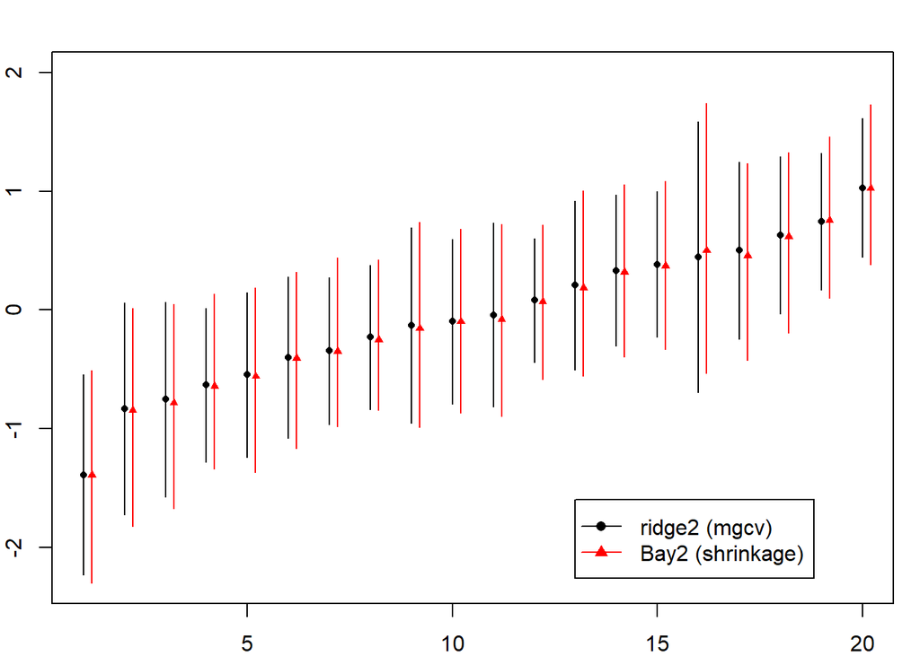

```r
par(mar=c(2,2,2,1))
ord <- order(pred2test$fit)[seq(1,100,length.out=20)]
plot(1:20,pred2test$fit[ord], pch=16,cex=0.7, ylim=c(-2.3,2), xlab="",ylab="")
points(1:20+0.2,pred_bay2[ord], pch=17,cex=0.7,col="red")
segments(1:20,cis[1,ord],1:20,cis[2,ord])
segments(1:20+0.2,cibay2_test[1,ord],1:20+0.2,cibay2_test[2,ord], col="red")
legend(13,-1.6, legend=c("ridge2 (mgcv)","Bay2 (shrinkage)"), col=c("black","red"),pch=c(16,17),
       lty=c(1,1))
```

## Logistic regression

loading libraries; using suppressWarnings() to avoid clutter

```r
suppressWarnings(library(rstan)) #available from CRAN
library(glmnet)
```

Load example training and test data set. These are simulated as in the manuscript, n=50, p=5 (+int), moderate setting ADJUST PATH, OR USE setwd()!

```r
load("binary_example.Rdata")

dim(train_bin)
```

```
## [1] 50  6
```

```r
head(train_bin)
```

```
##      Y         X1          X2         X3         X4         X5
## [1,] 1  1.2586249  0.17128510  0.3062174  0.5320799  1.4977116
## [2,] 0 -0.6885827 -0.01026401 -1.6449872 -0.2760017 -1.3452622
## [3,] 0  0.1310907 -1.12395528 -0.5531476 -1.1878112 -1.6377775
## [4,] 1 -1.5442303  0.93076897 -0.1147951 -0.1968388 -1.1666764
## [5,] 1  2.0501240  1.20533698  0.7872647  2.1503365  1.4844669
## [6,] 1  0.9818518  1.36605534  1.7205495  0.7324410  0.8577589
```

```r
colnames(train_bin)
```

```
## [1] "Y"  "X1" "X2" "X3" "X4" "X5"
```

Retrieve binary response and covariates

```r
Y <- train_bin[,1]
X <- train_bin[,-1]

dim(test_bin)
```

```
## [1] 50  6
```

```r
head(test_bin)
```

```
##      Y          X1          X2         X3         X4         X5
## [1,] 0  1.17364593 -0.24831277  0.5712094 -0.6121869 -0.6686368
## [2,] 1  2.18451419  0.02783932  0.2722058  0.8686717  1.2361516
## [3,] 0 -1.76416169 -2.27335711 -1.2887829 -1.9234391 -0.5587246
## [4,] 0 -0.08165222 -0.06624519  1.3988228 -0.2437450 -0.5073897
## [5,] 0  0.90191711  0.06025872  0.4841535  0.4205966 -0.6713133
## [6,] 0 -1.48163794 -2.95842986 -1.0293423 -1.7365273 -2.7936018
```

```r
Yte <- test_bin[,1]
Xte <- test_bin[,-1]
```

Glmnet with fixed ridge penalty, lambda = 1/tau^2 = 1/0.5 (ridge05), as advocated in Sullivan & Greenland (2013), Int J Epid. Note: glmnet scales loglik with n (see ?glmnet -> Details), so penalty parameter needs to be scaled accordingly

```r
n <- length(Y)
ridge05 <- glmnet(X, Y, alpha = 0, family="binomial", lambda=1/(n*0.5)) #alpha = 0 -> ridge regression
```

Coefficients, including intercept

```r
c(ridge05$a0,as.numeric(ridge05$beta))
```

```
##         s0
## 0.87473947 0.11311401 0.06932281 0.12941579 1.13646249 0.42090898
```

Predicted probabilities from glmnet on test set. Uncertainties are not provided.

```r
predridge05 <- predict(ridge05, newx=Xte, type="response")
predridge05[1:10]
```

```
##  [1] 0.52174687 0.93502170 0.11201870 0.63445314 0.77539404 0.05838681
##  [7] 0.64602630 0.11042374 0.88759314 0.53533561
```

Stan models need to be compiled once before fitting

```r
source('ExampleThinkShrink_functions.R')
```

Compiles stan code for Bayesian fits; takes some time.

```r
pmt <- proc.time()
stan_bin_brg_HalfCauchy <- stan_model(model_name = "stan_bin_brg_HalfCauchy", model_code = code_bin_brg_HalfCauchy)
stan_bin_brl_HalfCauchy <- stan_model(model_name = "stan_bin_brl_HalfCauchy", model_code = code_bin_brl_HalfCauchy)
proc.time()-pmt
```

```
##    user  system elapsed
##    1.22    0.19   63.50
```

```r
dat <- list(y = Y, X = X, n = nrow(X), p = ncol(X), a = 0.5, b = 0.5, sc=sqrt(0.5))
Bay_glob05 <- sampling(stan_bin_brg_HalfCauchy, data = dat, iter = 25000,
                           warmup = 5000, thin = 10, chain = 1)
```

Extensive summary

```r
summary(Bay_glob05)$summary
```

```
##                 mean     se_mean          sd         2.5%         25%
## alpha     0.95433988 0.009857698   0.4423863   0.18716947   0.6425594
## beta[1]   0.11055614 0.010034935   0.4452888  -0.84727796  -0.1533789
## beta[2]   0.06790677 0.009106956   0.3877650  -0.73090228  -0.1758316
## beta[3]   0.17008454 0.009025482   0.4051605  -0.60676622  -0.1059385
## beta[4]   1.18013944 0.013922877   0.5940692   0.20418626   0.7614277
## beta[5]   0.46556141 0.009981224   0.4299189  -0.29283132   0.1751839
## gam2     41.77676502 9.589320294 430.6920379   1.00732385   3.0558066
## tau2      0.79667173 0.023886514   1.0324901   0.07382024   0.2484468
## lp__    -27.44968550 0.051205493   2.2943020 -32.52590852 -28.8109299
##                  50%         75%       97.5%    n_eff      Rhat
## alpha     0.92195417   1.2219253   1.8822048 2013.967 1.0001982
## beta[1]   0.13635633   0.3814516   0.9539722 1969.039 1.0003118
## beta[2]   0.09323941   0.3250727   0.7844174 1812.971 0.9995660
## beta[3]   0.15338529   0.4390201   1.0247801 2015.178 0.9998050
## beta[4]   1.11268064   1.5511362   2.4945276 1820.607 0.9995100
## beta[5]   0.43548476   0.7256782   1.3732070 1855.263 0.9996194
## gam2      6.91726566  19.5333503 212.5521483 2017.242 0.9998632
## tau2      0.50016547   0.9243783   3.3092703 1868.384 0.9995176
## lp__    -27.10617240 -25.7454111 -24.0402124 2007.558 1.0001345
```

Posteriors of coefficients

```r
intpost <-  extract(Bay_glob05, "alpha")$alpha #posterior mcmc samples intercept
betapost <- extract(Bay_glob05, "beta")$beta #posterior mcmc samples five betas
dim(betapost)
```

```
## [1] 2000    5
```

Point estimates of coefficients (posterior means)

```r
intest <- mean(intpost)
betaest <- apply(betapost,2,mean)
c(intest,betaest)
```

```
## [1] 0.95433988 0.11055614 0.06790677 0.17008454 1.18013944 0.46556141
```

Compute posteriors of linear predictor and of predicted probabilities for test set

```r
etapost <- cbind(rep(1,nrow(Xte)),Xte) %*% t(cbind(intpost,betapost))
expit <- function(x) exp(x)/(1+exp(x))
probtestpost <- expit(etapost)
dim(probtestpost)
```

```
## [1]   50 2000
```

Predicted probabilities on test samples (posterior mean)

```r
predBay_glob05 <- apply(probtestpost,1,mean)
predBay_glob05[1:10]
```

```
##  [1] 0.52994925 0.91400420 0.15375320 0.64076695 0.76735627 0.09594153
##  [7] 0.65088870 0.14686173 0.87220357 0.52656253
```

Credible intervals for test set predictions

```r
ciBay_glob05  <- apply(probtestpost,1,quantile,probs=c(0.025,0.975))
ciBay_glob05[,1:10]
```

```
##            [,1]      [,2]        [,3]      [,4]      [,5]        [,6]      [,7]
## 2.5%  0.1765231 0.6998399 0.008268765 0.3084774 0.5028274 0.002471169 0.2706176
## 97.5% 0.8363849 0.9952186 0.501992517 0.9045266 0.9497797 0.412906999 0.9116999
##              [,8]      [,9]     [,10]
## 2.5%  0.007643027 0.6027809 0.2121128
## 97.5% 0.503534275 0.9873146 0.8329347
```

### Comparison ridge05 and Bay_glob05

Plot 20 test samples (of 50) to compare results of ridge05 (glmnet; black) with Bay_glob05 (stan; red); point predictions (both) and intervals (Bay_glob05 only)

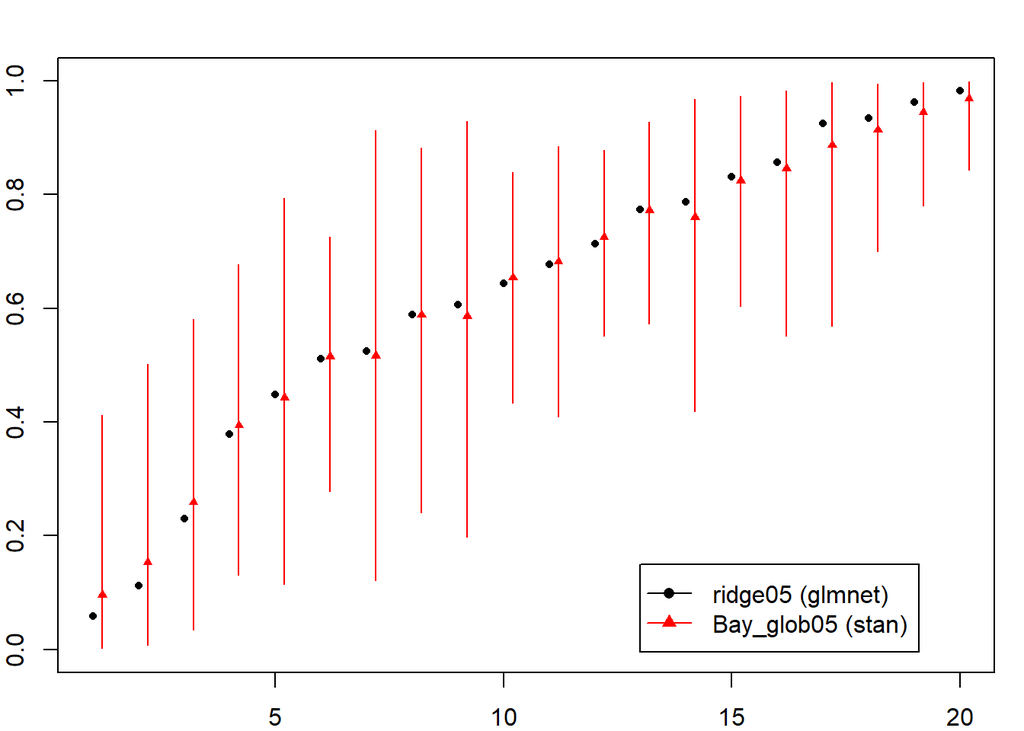

```r
par(mar=c(2,2,2,1))
ord <- order(predridge05)[seq(1,50,length.out=20)]
plot(1:20,predridge05[ord,1], pch=16,cex=0.7, ylim=c(0,1), xlab="",ylab="")
points(1:20+0.2,predBay_glob05[ord], pch=17,cex=0.7,col="red")
segments(1:20+0.2,ciBay_glob05[1,ord],1:20+0.2,ciBay_glob05[2,ord], col="red")
legend(13,0.15, legend=c("ridge05 (glmnet)","Bay_glob05 (stan)"), col=c("black","red"),pch=c(16,17),
       lty=c(1,1))
```

### Bayesian local (or grouped) shrinkage for logistic regression

Bayesian local shrinkage, beta[k] ~ N(0,tau2[k]), tau[k] ~ half-Cauchy(0,sqrt(0.5)) g indicates the groups, in this case each covariate is its own group; K is the number of covariate groups

```r
dat <- list(y = Y, X = X, g = 1:ncol(X), n = nrow(X), p = ncol(X), K = ncol(X),
            a = 0.5, b = 0.5, sc=sqrt(0.5))
```

Note: stan may give warnings for the sampling, as the local shrinkage factors (tau2[k]) are hard to estimate. Manuscript shows however that prediction results are are solid, and superior to those of max lik (which is comparable in the sense that it does not group covariates either)

```r
Bay_loc05 <- sampling(stan_bin_brl_HalfCauchy, data = dat, iter = 25000,
                      warmup = 5000, thin = 10, chain = 1)
```

```
## Warning: There were 212 divergent transitions after warmup. See
## https://mc-stan.org/misc/warnings.html#divergent-transitions-after-warmup
## to find out why this is a problem and how to eliminate them.
```

```
## Warning: Examine the pairs() plot to diagnose sampling problems
```

Extensive summary

```r
summary(Bay_loc05)$summary
```

```
##                  mean      se_mean           sd          2.5%           25%
## alpha      1.09342416 1.095596e-02 4.469400e-01  2.857525e-01  8.035806e-01
## beta[1]    0.05995458 1.090937e-02 3.551173e-01 -6.333363e-01 -1.037833e-01
## beta[2]    0.05138305 6.845179e-03 3.090864e-01 -5.694678e-01 -1.045041e-01
## beta[3]    0.20203889 5.653913e-02 3.929502e-01 -4.190176e-01 -3.406906e-02
## beta[4]    1.65467251 1.703448e-02 6.490308e-01  4.575786e-01  1.221765e+00
## beta[5]    0.31061310 4.182158e-02 4.562636e-01 -3.855601e-01 -4.151117e-04
## gam2[1]  472.82100372 9.743323e+01 4.339719e+03  1.019744e+00  5.313747e+00
## gam2[2] 6692.79145288 5.555697e+03 2.519705e+04  1.048802e+00  5.729850e+00
## gam2[3]  532.92508909 2.419682e+02 1.080212e+04  1.129354e+00  3.839032e+00
## gam2[4]   18.78338452 2.585902e+00 1.154153e+02  6.406554e-01  1.633578e+00
## gam2[5]  454.45931522 1.876156e+02 7.924287e+03  9.329939e-01  4.184749e+00
## tau2[1]    3.19140206 1.333287e+00 5.977932e+01  1.157398e-03  4.040543e-02
## tau2[2]    1.43063790 2.333950e-01 1.020955e+01  8.666392e-05  2.595264e-02
## tau2[3]    1.70998381 3.119329e-01 1.397596e+01  1.105737e-03  3.846348e-02
## tau2[4]   11.65817808 1.738452e+00 7.808480e+01  1.758440e-01  8.397392e-01
## tau2[5]    6.78238446 4.588772e+00 2.054787e+02  1.555248e-03  7.298333e-02
## lp__     -37.78435857 8.348822e-02 2.995373e+00 -4.447512e+01 -3.956204e+01
##                  50%         75%         97.5%      n_eff      Rhat
## alpha     1.05282120   1.3693565     2.0853136 1664.16904 0.9995241
## beta[1]   0.01282446   0.2144833     0.8644834 1059.60593 1.0035194
## beta[2]   0.01497302   0.1944909     0.7614686 2038.87273 0.9995275
## beta[3]   0.10790390   0.3718191     1.1071319   48.30330 1.0270010
## beta[4]   1.66932781   2.0337518     3.1282911 1451.68718 0.9999148
## beta[5]   0.23031249   0.5743535     1.3960881  119.02293 1.0145811
## gam2[1]  13.72221554  59.5865655  2961.3846043 1983.85048 0.9995877
## gam2[2]  18.89088854 113.9622714 98805.6070255   20.56943 1.0557632
## gam2[3]  14.74236690  72.6242653  2412.1736064 1992.97328 0.9998673
## gam2[4]   3.62079254   8.6658336   109.3766826 1992.06173 0.9996375
## gam2[5]  10.89108172  46.0474322  1751.7418960 1783.94956 0.9997289
## tau2[1]   0.13647010   0.5967953    10.3248574 2010.27121 0.9996839
## tau2[2]   0.12606615   0.5446697    10.7677826 1913.50717 0.9995031
## tau2[3]   0.18187134   0.7654374     9.1594663 2007.43247 0.9996299
## tau2[4]   2.06451452   5.5906990    65.9633268 2017.47162 0.9996711
## tau2[5]   0.30557838   0.8622516    13.6866454 2005.12230 1.0001160
## lp__    -37.71709219 -35.6726176   -32.8142984 1287.21560 0.9995216
```

Covariate groups; e.g. global shrinkage for cov 1,2,3,5 and local for cov 4. Set number of covariate groups K=2

```r
covgroups <- c(1,1,1,2,1)
dat <- list(y = Y, X = X, g = covgroups, n = nrow(X), p = ncol(X), K = 2,
            a = 0.5, b = 0.5, sc=sqrt(0.5))
Bay_205 <- sampling(stan_bin_brl_HalfCauchy, data = dat, iter = 25000,
                      warmup = 5000, thin = 10, chain = 1)
```

Extensive summary (should shrink beta4 estimate less than Bay_glob05)

```r
summary(Bay_205)$summary
```

```
##                 mean      se_mean           sd          2.5%           25%
## alpha     1.07555518 1.143342e-02    0.4517280   0.248795514   0.761763736
## beta[1]   0.02989309 7.023537e-03    0.2860650  -0.544563580  -0.104306580
## beta[2]   0.03007003 6.072199e-03    0.2744232  -0.586735649  -0.096393355
## beta[3]   0.11256941 6.342723e-03    0.2799452  -0.379184655  -0.043432413
## beta[4]   1.72034522 1.775965e-02    0.6433384   0.589773509   1.267698442
## beta[5]   0.22165220 8.087007e-03    0.3322326  -0.234521692   0.007783779
## gam2[1] 458.87343021 1.652857e+02 2364.8343331   1.773301288   8.515738956
## gam2[2]  34.34573311 1.043726e+01  437.0926455   0.625949664   1.794534207
## tau2[1]   0.19941796 1.193655e-02    0.5163694   0.001045277   0.021740811
## tau2[2]  14.53162890 1.752755e+00   79.2058616   0.231829840   1.215085152
## lp__    -26.96218870 1.184689e-01    3.3972379 -34.236621704 -29.029616497
##                  50%         75%        97.5%     n_eff      Rhat
## alpha     1.05394043   1.3591798    2.0167641 1560.9953 0.9998046
## beta[1]   0.01772686   0.1680191    0.6336677 1658.8905 0.9996115
## beta[2]   0.02555633   0.1688884    0.5982801 2042.4412 0.9995110
## beta[3]   0.06529118   0.2534728    0.7640756 1948.0259 0.9998852
## beta[4]   1.68115754   2.1390633    3.0537645 1312.2307 1.0014135
## beta[5]   0.13780360   0.3806668    1.0391484 1687.7523 0.9999572
## gam2[1]  28.82133450 139.2053690 3060.1668274  204.7061 1.0021222
## gam2[2]   3.64718898   8.6392124  116.7758072 1753.7756 1.0003333
## tau2[1]   0.07705926   0.2070040    1.0349796 1871.3850 1.0013496
## tau2[2]   2.74313568   7.8246012   90.4829548 2042.0783 0.9999650
## lp__    -26.85954102 -24.8516138  -20.3234981  822.3243 1.0023629
```

```r
summary(Bay_glob05)$summary
```

```
##                 mean     se_mean          sd         2.5%         25%
## alpha     0.95433988 0.009857698   0.4423863   0.18716947   0.6425594
## beta[1]   0.11055614 0.010034935   0.4452888  -0.84727796  -0.1533789
## beta[2]   0.06790677 0.009106956   0.3877650  -0.73090228  -0.1758316
## beta[3]   0.17008454 0.009025482   0.4051605  -0.60676622  -0.1059385
## beta[4]   1.18013944 0.013922877   0.5940692   0.20418626   0.7614277
## beta[5]   0.46556141 0.009981224   0.4299189  -0.29283132   0.1751839
## gam2     41.77676502 9.589320294 430.6920379   1.00732385   3.0558066
## tau2      0.79667173 0.023886514   1.0324901   0.07382024   0.2484468
## lp__    -27.44968550 0.051205493   2.2943020 -32.52590852 -28.8109299
##                  50%         75%       97.5%    n_eff      Rhat
## alpha     0.92195417   1.2219253   1.8822048 2013.967 1.0001982
## beta[1]   0.13635633   0.3814516   0.9539722 1969.039 1.0003118
## beta[2]   0.09323941   0.3250727   0.7844174 1812.971 0.9995660
## beta[3]   0.15338529   0.4390201   1.0247801 2015.178 0.9998050
## beta[4]   1.11268064   1.5511362   2.4945276 1820.607 0.9995100
## beta[5]   0.43548476   0.7256782   1.3732070 1855.263 0.9996194
## gam2      6.91726566  19.5333503 212.5521483 2017.242 0.9998632
## tau2      0.50016547   0.9243783   3.3092703 1868.384 0.9995176
## lp__    -27.10617240 -25.7454111 -24.0402124 2007.558 1.0001345
```